# Implementing Gaussian Mixture Models (GMM) and k-means clustering in R on simulated data

Jacob L. Fine

April 4th, 2024

**Description:**

We are often interested in identifying sub-populations that have distinct probablity distributions in a population of values, the parameters of which may be estimated by numerical methods. The purpose of this demonstration is to show that three underlying multivariate Gaussian distributions, when combined into a mixture of Gaussian distributions, can be re-identified by unsupervised learning. We will implement the Expectation-Maximization (EM) algorithm, a key numerical method widely used in statistical inference, to estimate the parameters of each multivariate Gaussian component. We will also implement the k-means clustering algorithm to do the same. We will then show that the estimated means resemble the original sample means of the noise-adjusted component distributions.

**Step 1:** Import libraries

```r
# Sets the seed
set.seed(2000127)
# Checks if the mclust package is installed, else, installs it
if (!requireNamespace("mclust", quietly = TRUE)) {
  install.packages("mclust")
}
# Checks if the MASS package is installed, esle, installs it
if (!requireNamespace("MASS", quietly = TRUE)) {
  install.packages("MASS")
}

# Loads the necessary packages
library(mclust)
library(MASS)

# Checks if the packages are installed, else, installs it

if (!requireNamespace("knitr", quietly = TRUE)) {
  install.packages("knitr")
}
if (!requireNamespace("kableExtra", quietly = TRUE)) {
  install.packages("kableExtra")
}
library(knitr)
library(kableExtra)
```

**Step 2:** Simulate and plot the data from multivariate Gaussian distributions

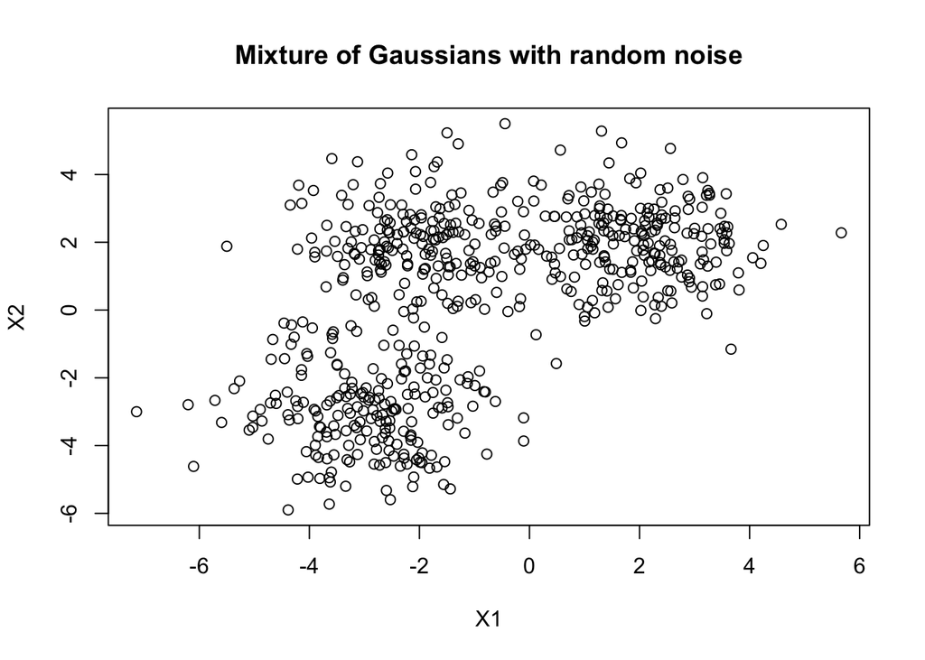

```r
# selects the number of samples to use
n_samples <- 200

# sets the covariance matrix
c_matrix <- c(1, 0, 0, 1)

# sets the means vectors
mean_1 <- c(2,2)
mean_2 <- c(-2,2)
mean_3 <- c(-3,-3)
# simulates data from multivariate normal distributions
data1 <- mvrnorm(n_samples, mu = mean_1, Sigma = matrix(c_matrix, nrow = 2))
data2 <- mvrnorm(n_samples, mu = mean_2, Sigma = matrix(c_matrix, nrow = 2))
data3 <- mvrnorm(n_samples, mu = mean_3, Sigma = matrix(c_matrix, nrow = 2))


# adds random noise to each datapoint in the matirx, by adding random numbers between -a and +a
# the threshold of noise to add to
a = 1
data1 <- data1 +  matrix(runif(nrow(data1)*ncol(data1), min = -a, max = a), ncol = 2)
data2 <- data2 +   matrix(runif(nrow(data1)*ncol(data1), min = -a, max = a), ncol = 2)
data3 <- data3 +   matrix(runif(nrow(data1)*ncol(data1), min = -a, max = a), ncol = 2)

# Concatenates the rows of each MV distribution to make a combined distribution
data <- rbind(data1, data2, data3)
# Plots the datapoints, recalling where each MV Gaussian came from
plot(data,
     main = "Mixture of Gaussians with random noise", xlab = "X1", ylab = "X2")
```

```r
# computes the mean of each underlying random variable after noise adjustment
mean_data1 <- colMeans(data1)
mean_data2 <- colMeans(data2)
mean_data3 <- colMeans(data3)

# concatenates them
all_means <- c(mean_data1, mean_data2, mean_data3)

# reshapes the means into a 2x3 matrix
means_ground_truth <- t(matrix(all_means, nrow = 3, byrow = TRUE))
```

**Step 3:** Construct a GMM using the EM algorithm, and plot results

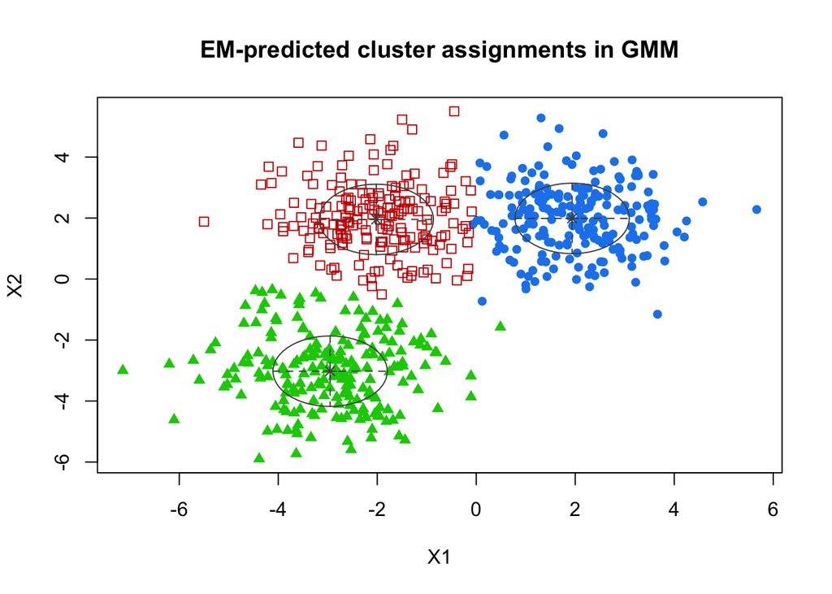

```r
gmm_model <- Mclust(data, G = 3)

# For each datapoint, the probability that it belongs to each cluster
cluster_probs <- predict(gmm_model, classification = "posterior")

# Plots the classification of each datapoint
plot(gmm_model, what = "classification", xlab = "X1", ylab = "X2")
title("EM-predicted cluster assignments in GMM")
```

```r
# returns the EM parameter estimates of the noise-adjusted Gaussian components
GMM_means <- gmm_model$parameters$mean
covariances <- gmm_model$parameters$variance$sigma
mixing_coefficients <- gmm_model$parameters$pro
```

**Step 4:** Implement k-means clustering to compare estimates with GMM

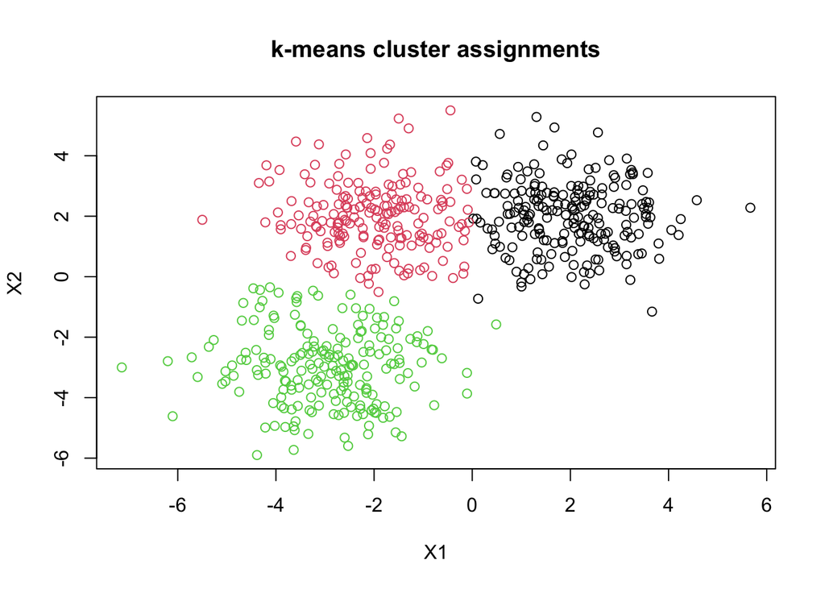

```r
# perform k-means clustering with three predicted clusters
kmeans_result <- kmeans(data, centers = 3)

# plot results
plot(data, col = kmeans_result$cluster, main = "k-means cluster assignments", xlab = "X1", ylab = "X2")
```

```r
# gett the cluster centers
cluster_centers <- kmeans_result$centers
cluster_centers <- t(cluster_centers)


# determines the number of negatives in each col to reorganize based on this
count_negative_values <- function(col) {
  sum(col < 0)
}
negative_counts <- apply(cluster_centers, 2, count_negative_values)

# sorts the columns based on number of negative values per col
order_indices <- order(negative_counts)
cluster_centers_reordered <- cluster_centers[, order_indices]
colnames(cluster_centers_reordered) <- NULL
kmeans_means <- cluster_centers_reordered
```

**Step 5:** Compare the EM-estimated means and the k-means estimated means with the parameters we would have obtained by computing sample means in the original component distributions.

```r
# sets the column titles
column_titles <- c("sub-pop. 1", "sub-pop. 2", "sub-pop. 3")
colnames(means_ground_truth) <- column_titles

# the caption for the table
caption_html <- "<b>Sample means (ground truth)</b>"

# Plots the original means
kable(means_ground_truth, caption = caption_html) %>%
  kable_styling(full_width = FALSE) %>%
  scroll_box(width = "100%")
```

**Sample means (ground truth)**

| sub-pop. 1 | sub-pop. 2 | sub-pop. 3 |
| --- | --- | --- |
| 2.025345 | -1.888759 | -2.960068 |
| 2.019318 | 1.928818 | -3.018832 |

```r
# computes the mean squared difference between the estimated parameters (GMM) and the sample means of original Gaussians
MSE = mean((GMM_means-means_ground_truth)^2)
MSE <- format(MSE, scientific = TRUE, digits = 2)

# Adds the MSE value to the title
title_with_mse <- paste("<b>Means (GMM)<\b>, MSE =", MSE)

column_titles <- c("sub-pop. 1", "sub-pop. 2", "sub-pop. 3")
colnames(GMM_means) <- column_titles

# Plots the estimated means
kable(GMM_means, caption = title_with_mse) %>%
  kable_styling(full_width = FALSE) %>%
  scroll_box(width = "100%")
```

**Means (GMM), MSE = 4.5e-03**

| sub-pop. 1 | sub-pop. 2 | sub-pop. 3 |
| --- | --- | --- |
| 1.937015 | -2.019956 | -2.952117 |
| 1.988647 | 1.955029 | -3.021355 |

```r
# computes the mean squared difference between the estimated parameters (k-means) and the sample means of original Gaussians
MSE = mean((kmeans_means-means_ground_truth)^2)
MSE <- format(MSE, scientific = TRUE, digits = 2)

column_titles <- c("sub-pop. 1", "sub-pop. 2", "sub-pop. 3")
colnames(kmeans_means) <- column_titles

# Adds the MSE value to the title
title_with_mse <- paste("<b>Means (k-means)<\b>, MSE =", MSE)

# Plots the estimated means
kable(kmeans_means, caption = title_with_mse) %>%
  kable_styling(full_width = FALSE) %>%
  scroll_box(width = "100%")
```

**Means (k-means), MSE = 3.6e-03**

| sub-pop. 1 | sub-pop. 2 | sub-pop. 3 |
| --- | --- | --- |
| 1.999016 | -2.011706 | -2.957041 |
| 1.999024 | 1.998266 | -2.993145 |